# Seattle Pacific University

[SPU Stay Smart – COVID-19 Response](https://spu.edu/administration/smart-start)

25% Tuition Reduction.

Imagine your future at SPU

### Academic

### Faith

### Seattle

#### Seattle

#### Check us out in 360

Our state-of-the-art virtual tour will let you walk through campus, check out your residence hall, soar over the Seattle waterfront, and more.

Take the tour

[figure not shown]

About us

**We are a nationally ranked, private Christian liberal arts university in Seattle, Washington.**

We are fully committed to graduating people of competence and character, becoming people of wisdom, and modeling a grace-filled community.

Undergraduate

[Request information](https://spu.edu/undergraduate-admissions/request-info)

[Visit SPU](https://spu.edu/undergraduate-admissions/visit)

[Apply now](https://spu.edu/undergraduate-admissions/apply)

Graduate

[Request information](https://spu.edu/graduate-admissions/admissions/request-more-info)

[Explore programs](https://spu.edu/graduate-admissions/degree-programs)

[Apply](https://admissions.spu.edu/apply/)

# Degrees & Programs

Seattle Pacific is recognized by *U.S. News & World Report* for its full range of undergraduate and graduate programs — more than 170 areas of study — and its commitment to groundbreaking research.

[Undergraduate](https://spu.edu/undergraduate-admissions/majors-academics)

[Graduate](https://spu.edu/graduate-admissions/degree-programs)

[Certificates](https://spu.edu/academics/school-of-education/education-programs/certification-endorsements)

Among the best

[video not shown]

### Named a “Best National University” for the fifth year in a row.

*U.S. News & World Report*, 2021

[video not shown]

Tuition Reimagined

**25% tuition reduction**

Seattle Pacific commits to a 25% undergraduate tuition rate reduction, new scholarships, a cap on future tuition increases, and more.

[Find out more](https://youtu.be/vI8NfcnPMu4)

Our distinctives

# 93%

**Graduates employed or in grad school one year after graduation**

# 43%

**Ethnic diversity of undergraduate students**

# 174

**Academic programs offered**

# 13:1

**Student-faculty ratio**

# 3,529

**Total enrollment**

# 95%

**Undergraduates who receive financial aid**

# 98%

**Alumni who say SPU’s academic quality met or exceeded their expectations**

# 12

**NCAA Division II sports teams**

[Undergraduate student profile](https://spu.edu/diversity/faq/student-profile)

[Graduate student profile](https://spu.edu/diversity/faq/student-profile-grad)

[Career Outcomes](https://spu.edu/undergraduate-admissions/outcomes)

[Office of Institutional Effectiveness](https://spu.edu/administration/office-of-institutional-effectiveness)

# News/Stories

[figure not shown]

Featured

**Meet Mehdi El Mardi, who is pursuing a master’s degree in data analytics and playing basketball with the Falcons.**

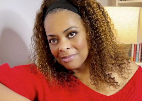

Podcast

**Alumna Michelle Lang-Raymond, co-founder of Acts on Stage Theater, talks about the company's mission to increase opportunities for artists of color and activists of faith.**

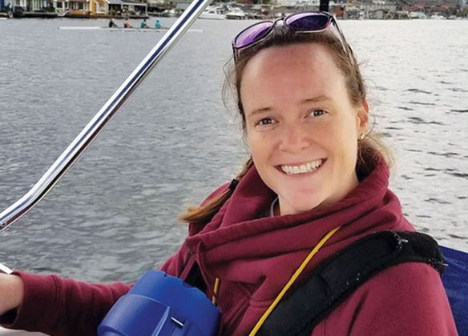

Athletics

**Falcons new rowing coach Caitlin McClain served in several coaching positions with the U.S. women's national team.**

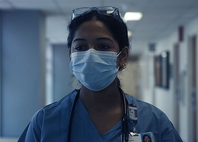

Newsroom

**Seattle Pacific’s documentary short film, “Time to Heal,” selected for viewings at three regional film festivals.**

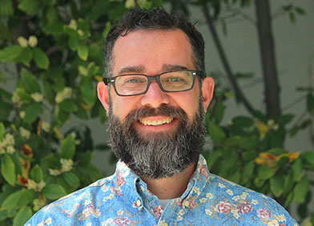

Featured

**The School of Theology and Seattle Pacific Seminary welcome the Rev. Dr. Brian Lugioyo as its new dean.**

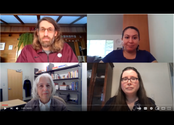

Featured

**Four SPU biology professors answer some of the most common questions about COVID-19 and vaccines.**

[Newsroom](https://spu.edu/about-spu/press-room)

[SPU Stories](https://spu.edu/stories)

[Athletics](https://spufalcons.com/)

SPU Stories

### Top reasons we think a private university is the way to go

See the reasons

SPU Stories

### Todd Jacobsen is where the wild things are

Read the article

Social media

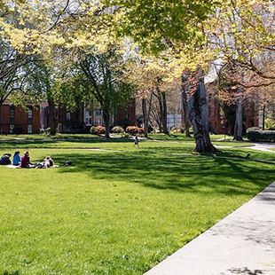

[figure not shown]

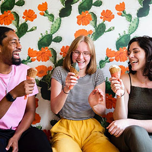

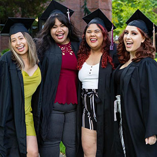

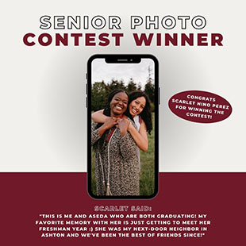

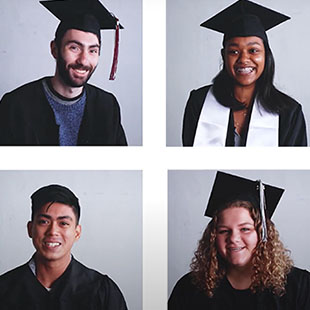

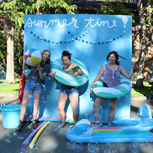

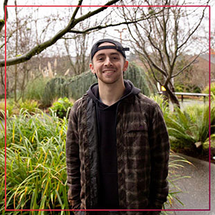

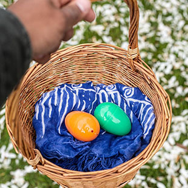

[figure not shown]

[Instagram](https://instagram.com/seattle_pacific)

[Facebook](https://facebook.com/seattle.pacific.university)

[Twitter](https://twitter.com/seattlepacific)

[3307 3rd Ave West, Seattle WA 98119-1997](https://goo.gl/maps/fQq2afgcegNgCeqKA)

206-281-2000

## Policy

© 2021 Seattle Pacific University